# The role of chemical cue similarity in interactions between ants and native versus non-native lady beetles in North America - ScienceDirect

## Figures (3)

## [Animal Behaviour](https://www.sciencedirect.com/journal/animal-behaviour)

[Volume 203](https://www.sciencedirect.com/journal/animal-behaviour/vol/203/suppl/C), September 2023, Pages 21-28

# The role of chemical cue similarity in interactions between ants and native versus non-native lady beetles in North America

https://doi.org/10.1016/j.anbehav.2023.06.005[Get rights and content](https://s100.copyright.com/AppDispatchServlet?publisherName=ELS&contentID=S0003347223001562&orderBeanReset=true)

Under a Creative Commons [license](http://creativecommons.org/licenses/by/4.0/)

open access

## Highlights

- •

  Cue similarity and interference interactions might reveal the real novelty of species.
- •

  Congeneric native and non-native lady beetles share similar cuticular hydrocarbons.
- •

  No clear pattern between ant aggression, beetle origin and chemical cue similarity.
- •

  Additional traits of lady beetles might contribute to ant aggression.

While native species' interactions underlie coevolution, non-native species might benefit from their novel cues and a lack of recognition, resulting in potential competition advantages in interactions. In predator–predator interactions for example, non-native predators bearing novel cues might experience reduced interference. However, non-native predators might experience similar interference if their cues are similar to those of native predators, such as in congeneric species. Here, we studied aggressive responses by ants towards several native and non-native [lady beetles](https://www.sciencedirect.com/topics/agricultural-and-biological-sciences/coccinellidae), and in turn compared the responses of these lady beetle species to ants. We expected strongest ant aggression towards coevolved native North American lady beetles, intermediate aggression towards non-native, congeneric lady beetles (due to potential cue similarities) and least aggression towards the non-native *[Harmonia axyridis](https://www.sciencedirect.com/topics/agricultural-and-biological-sciences/harmonia-axyridis)*. A similar ranking was expected for the lady beetle responses to ants. Furthermore, we analysed cuticular hydrocarbons (CHCs) of all lady beetle species and tested for similarities of CHCs between congeneric native and non-native species in the genera *[Coccinella](https://www.sciencedirect.com/topics/agricultural-and-biological-sciences/coccinella)* and *[Hippodamia](https://www.sciencedirect.com/topics/agricultural-and-biological-sciences/hippodamia)*. Overall, similar ant aggression towards different lady beetle species could not be attributed only to cue similarities between them, suggesting that ants might additionally respond to different defensive traits of lady beetles. Surprisingly, we found CHC similarities not only between congeneric native and non-native lady beetles, but also between non-native *H. axyridis* and both *Hippodamia* species. Despite similar ant aggression, reaction [behaviour](https://www.sciencedirect.com/topics/neuroscience/behavior-neuroscience) of the native *[Coleomegilla maculata](https://www.sciencedirect.com/topics/agricultural-and-biological-sciences/coleomegilla-maculata)* was relatively strong compared to that of non-native lady beetles, suggesting a low tolerance towards ant attacks. In particular, during times of food scarcity, non-native lady beetle species that are tolerated by ants might have an advantage over less-tolerated native lady beetles. Future field studies on ant–lady beetle–aphid interactions are required to shed light on ant tolerance and competitive advantages of non-native lady beetle species.

## Keywords

ant aggression

chemical cue

Coccinellidae

intraguild interference

invasion

Predator–predator interactions can shape prey and predator population dynamics (Sih et al., 1998). For example, if the foraging activity of one predator enhances the predation success of another predator, this interaction will increase the suppression of prey populations (Losey & Denno, 1998). Alternatively, prey populations may benefit from antagonistic interactions between predators, such as intraguild predation or predator-induced foraging disruption, which can bring about changes in predator populations (Rosenheim et al., 1995; Polis et al., 1989). Intraguild interference describes temporally and spatially coinciding predators competing over a shared resource, in which direct predator interactions limit the access to a resource (Putman & Putman, 1994). These interactions can decrease fitness of a subordinate predator by, for example, aggressive predatory encounters (Eccard & Ylönen, 2002).

Non-native predators can destabilize native communities by changing their structure and function (Wagner & Van Driesche, 2010). For example, the invasion of the Argentine ant, *[Linepithema humile](https://www.sciencedirect.com/topics/agricultural-and-biological-sciences/linepithema-humile)*, altered the native ant community structure (Sanders et al., 2003) and ant diversity in North America (Human & Gordon, 1997). This invasive ant species had further consequences for adjacent [trophic levels](https://www.sciencedirect.com/topics/agricultural-and-biological-sciences/trophic-level), for example reduced [seed dispersal](https://www.sciencedirect.com/topics/agricultural-and-biological-sciences/seed-dispersal) of native plant species by native ants (Bond & Slingsby, 1984). The interference with coevolved interaction networks can lead to novel interactions (Carthey & Banks, 2014; Verhoeven et al., 2009). The lack of coevolution between non-native predators and native prey can result in missing cue recognition and consequently lack of antipredator behaviours by native prey (Banks & Dickman, 2007; Carthey et al., 2017; Sih et al., 2010). For example, flightless birds in New Zealand do not flee from invasive mammalian predators and thus suffer heavy predation (Blackwell, 2005). Similarly, non-native predators might remain undetected by native competitors in intraguild interactions. Consequently, non-native predators are expected to be stronger competitors for shared prey than native predators, which might contribute to their invasion success (Banks & Dickman, 2007; Cox & Lima, 2006; Sih et al., 2010).

However, the success of non-native predators can depend on their similarity to native species. Non-native predators might not benefit from having cue novelty if they possess similar cues as their native counterparts and therefore elicit similar antipredator behaviour (Sih et al., 2010). The combined analysis of cue similarity and interference interactions between congeneric native and non-native species could provide insights into the true ‘novelty’ of a taxonomically related species and their role in non-native habitats (Sih et al., 2010). Based on the evolution of intraspecific signals, [pheromone blends](https://www.sciencedirect.com/topics/agricultural-and-biological-sciences/pheromone-blends) of species can evolve gradually by minor changes in components, resulting in similarities between closely related species. Alternatively, pheromones can underlie saltatory shifts and major changes in pheromone compositions compared to their antecedents (reviewed in Symonds & Elgar, 2008; Menzel et al., 2017). Magro et al. (2010) found that the tracks (chemical substances released while walking) of different lady beetle species, which can serve, for example, as an intraspecific oviposition-deterring pheromone, were more similar between closely related species of the same genera, compared to species from different genera. This suggests [phylogenetic](https://www.sciencedirect.com/topics/neuroscience/phylogenetics) conservatism (Symonds & Elgar, 2008). The tracks of lady beetles consist of cuticular hydrocarbons (CHCs) and are similar, if not identical, to the CHC composition on lady beetles' elytra (Kosaki & Yamaoka, 1996; Geiselhardt et al., 2011). Research on aphid–lady beetle, as well as ant–lady beetle, interactions further indicates that CHCs of lady beetles might serve as predator/competitor cues and mediate interspecific communication (Ninkovic et al., 2013; Bucher et al., 2021).

Lady beetles are predators of aphids and coccids and have therefore been globally introduced as [biological control agents](https://www.sciencedirect.com/topics/agricultural-and-biological-sciences/biological-control-agents) for pest control (Harmon et al., 2007). Invasive lady beetle species are associated with a decline in native lady beetle species. This was shown for the Asian *Harmonia axyridis* in Europe and North America (Roy et al., 2016) and the European *Coccinella septempunctata* in North America (Evans, 2000). Compared to many native [Coccinellids](https://www.sciencedirect.com/topics/agricultural-and-biological-sciences/coccinellids), both species are relatively large in body size, highly fecund and voracious (Kajita & Evans, 2010; Elliott et al., 1996; Hoki et al., 2014; Ünlü, Obrycki, et al., 2020; Ünlü, Terlau, et al. 2020). Moreover, both species are often superior to native lady beetles in intraguild interactions such as resource competition or intraguild predation (Obrycki et al. 1998; Michaud, 2002; Alyokhin & Sewell, 2004; Ware et al., 2009). Most studies have focused on intraguild interactions between lady beetle species (e.g. Lucas, 2013; Moser & Obrycki, 2009) and far less is known about interactions between ants and lady beetles (Majerus et al., 2007).

Ants frequently tend and/or prey on aphids and thus represent competitors for lady beetles (Way, 1963). In lady beetle–ant interactions, aggression of ants towards lady beetles, as well as defensive behaviours of lady beetles upon ant attacks, varies strongly among species (see Bucher et al., 2021; Finlayson et al., 2009). Chemical cues consisting of CHCs play a key role for intra- and interspecific communication in ants (Binz et al., 2014; Greene & Gordon, 2003; Wüst & Menzel, 2017). Previous studies demonstrated that cuticular hydrocarbons of parasitoid and predator species can serve as interspecific cues, inducing [aggressive behaviour](https://www.sciencedirect.com/topics/neuroscience/aggression) in ants (Dettner & Liepert, 1994; Pasteels, 2007; Bucher et al., 2021). A lack of cue recognition of non-native lady beetles with distinct chemical cues might result in lower aggression behaviour by ants compared to native lady beetle species. Lady beetles possess behavioural strategies to respond to ant interference, such as flying or running away (Bradley, 1973; Finlayson et al., 2009). These behaviours can reduce the effect of an ant attack but might further indicate reduced competition strength over ant-tended aphids compared to more ‘ant-tolerant’ lady beetles. For example, disturbances in feeding activity of lady beetles by ant aggression can be energetically costly, by reducing time spent foraging and feeding (Finlayson et al., 2009). Specifically, competition over ant-tended aphids occurs when food resources for lady beetles are scarce (Sloggett & Majerus, 2000). Relatively few studies have investigated the reaction of native and non-native lady beetle species to ant attacks, which could serve as a competitive advantage in exploiting food resources in times of scarcity (Bucher et al., 2021; Finlayson et al., 2009; Pell et al., 2008). Thus, competitive foraging and feeding advantages over native lady beetle species, involving ant-tended prey might contribute to the invasion of non-native lady beetle species (Finlayson et al., 2009).

Here, we tested the strength of intraguild interactions between two native North American ant species, *[Lasius](https://www.sciencedirect.com/topics/agricultural-and-biological-sciences/lasius)* *neoniger* and *[Myrmica](https://www.sciencedirect.com/topics/agricultural-and-biological-sciences/myrmica)* *americana*, and native and non-native lady beetle species. Our species set consisted of three native North American lady beetle species, *Coleomegilla maculata*, *Coccinella novemnotata* and *Hippodamia convergens*, two non-native congeneric European lady beetle species, *C. septempunctata* and *Hippodamia variegata*, and the non-native Asian lady beetle species, *H. axyridis*. We expected the highest aggression by ants towards coevolved native lady beetles, intermediate aggression towards non-native, congeneric lady beetles (due to potential cue similarities) and lowest aggression towards non-native *H. axyridis*. We simultaneously assessed lady beetle reaction upon contact with ants. For the reaction of lady beetles upon ant attack, we expected a similar pattern as for ant aggression; the strongest reaction by coevolved lady beetles, an intermediate reaction by non-native congeneric species and the lowest reaction by non-native *H. axyridis*. In addition, we analysed the CHC composition on lady beetles’ elytra. We expected species-specific CHC profiles, but similarities of CHCs between congeneric native and non-native lady beetle species.

## Methods

### Study Species

Ants were collected at agricultural field margins at the North Farm research field station of the University of Kentucky (Lexington, KY, U.S.A.) from May to June 2018. We excavated [ant colonies](https://www.sciencedirect.com/topics/agricultural-and-biological-sciences/ant-colonies) with brood from the ground and kept them in a terrarium (23.0 × 15.3 cm and 16.5 cm high; *L. neoniger*) or buckets (38.1 × 26.67 cm; *M. americana*). Colonies of *L. neoniger* colonies and *M. americana* were maintained in the laboratory (22 ± 1 °C and 25 ± 1 °C, respectively, and light 16:8 h light:dark). We used three *L. neoniger* colonies and two *M. americana* colonies for the aggression experiments with [lady beetles](https://www.sciencedirect.com/topics/agricultural-and-biological-sciences/coccinellidae). Ant colonies were supplied daily with honey and water and fed weekly with freeze-killed crickets and grasshoppers, collected from the research field station. Adult *Col. maculata*, *C. septempunctata* and *H. axyridis* were collected at the same locality as the ants (North Farm, Lexington, KY, U.S.A.) in alfalfa, soybean and [corn](https://www.sciencedirect.com/topics/agricultural-and-biological-sciences/maize) fields from May to September 2018. *Hippodamia variegata* was collected from an alfalfa field in Le Roy, IL, U.S.A. in May and June. *[Hippodamia convergens](https://www.sciencedirect.com/topics/agricultural-and-biological-sciences/hippodamia-convergens)* was purchased from Rincon Vitova [Insectaries](https://www.sciencedirect.com/topics/agricultural-and-biological-sciences/insectaries), Ventura, CA, U.S.A., in April 2018. *[Coccinella](https://www.sciencedirect.com/topics/agricultural-and-biological-sciences/coccinella)* *novemnotata* larvae were purchased from the Lost Ladybug Project, Cornell University, Ithaca, NY, U.S.A., since no individuals were found in Kentucky. Lady beetle larvae were kept separately in glass vials until they developed into adults. The adult lady beetles were sorted by species and stored in plastic boxes. They were provided with water and fed ad libitum with [pea aphids](https://www.sciencedirect.com/topics/agricultural-and-biological-sciences/acyrthosiphon-pisum), *Acyrthosiphon pisum*, and thawed *[Ephestia kuehniella](https://www.sciencedirect.com/topics/agricultural-and-biological-sciences/ephestia-kuehniella)* eggs and kept in chambers (22 ± 1 °C, light 16:8 h light:dark). For the chemical analysis of CHCs, lady beetles were separated by species and freeze-killed (−7 ± 1 °C) in petri dishes (9.4 × 1.6 cm). Voucher specimens were preserved in ethanol (70%) and stored at −7 ± 1 °C at the Department of Entomology (Animal Pathology Building), at the University of Kentucky.

### Aggression Experiments

We used a round petri dish (9.4 × 1.6 cm) as an experimental arena for the ant aggression bioassays. Fluon was applied on the petri dish wall to prevent ants from leaving. Three individuals from one ant colony were randomly collected, placed inside the petri dish and acclimatized for 15 min prior to the start of the experiments. A single adult lady beetle was placed into the petri dish and lady beetle and ant [behaviours](https://www.sciencedirect.com/topics/neuroscience/behavior-neuroscience) were quantified over 3 min. The following ant aggression behaviours were quantified: chasing, grasping, biting and stinging (stinging for *M. americana* only; see Bucher et al., 2021). Lady beetle reaction was quantified as turning on back, flailing legs, fluttering wings, backing, running away and flying away (see Finlayson et al., 2009). Aggression or reaction behaviours that lasted longer than 3 s were quantified as new behaviours to put more weight on long-lasting interactions. We compared six lady beetle species in combination with two ant species with at least 19 replicates per species combination, resulting in 243 replicates (122 *L. neoniger* interactions, 121 *M. americana* interactions). All behavioural assays were recorded with a video camera (LUMIX DMC-FZ300, Panasonic Corporation, Kadoma, Osaka, Japan) mounted on a tripod. Videos were analysed in slow motion if interactions and behaviours occurred too quickly to be visually quantified during the experiments. Experiments were conducted in the laboratory at 26.8 ± 0.1 °C and artificial light.

### Preparation of Species-specific Cue Solutions

[Elytra](https://www.sciencedirect.com/topics/agricultural-and-biological-sciences/elytra) of one freeze-killed lady beetle per sample were immersed in 1.0 ml hexane for 10 min so that CHCs were dissolved. We sampled seven *C. maculata*, eight *C. novemnotata*, six *H. convergens*, six *C. septempunctata*, seven *H. variegata* and seven *H. axyridis* individuals. We concentrated all samples under a gentle flow of nitrogen and injected them into a 7890A gas chromatograph coupled to a 5975C mass spectrometer (Agilent Technologies Inc., Santa Clara, CA, U.S.A.) in the splitless mode at 250 °C. We used helium as carrier gas (1.2 ml/min) and a capillary column (Phenomenex Zebron ZB5-HT Inferno, 30 m × 0.25 μm × 0.25 μm) as stationary phase. Oven temperature was 60 °C for 2 min, then this was increased to 200 °C by 60 °C/min, followed by an increase to 320 °C by 4 °C/min, where it remained constant for 10 min. We used an ionization current of 70 eV and scanned molecular fragments from 40 to 650 m/z. Data were acquired using the software MSD Chem Station E.02.02 (Agilent Technologies). We analysed all hydrocarbons with a chain length >C20 and an average abundance of at least 0.5%; the abundance of all hydrocarbons <C20 totalled less than 1% of the total. Substances were identified based on retention time and diagnostic ions. The relative abundances of CHCs of lady beetles were calculated and used for further analysis (see Bucher et al., 2021).

### Ethical Note

Our research followed the ASAB/ABS Guidelines for the Use of Animals in Research. Both ant species, *L. neoniger* and *M. americana*, the native North American lady beetle species *C.a maculata*, *H. convergens*, *C. novemnotata* and the non-native *C. septempunctata*, *H. variegata* and *H. axyridis* are not listed as threatened species and require no licence to be studied. All species were maintained under optimal laboratory conditions and were provided with food on a regular schedule. Lady beetles were freeze-killed prior to chemical extractions.

### Statistical Analysis

To analyse differences in aggression or reaction behaviour, we applied generalized linear mixed models (GLMMs). We calculated the frequency of aggression behaviours of ants and reaction behaviours of lady beetles and we refer to this as aggression or reaction strength. The response variables were aggression frequency or reaction frequency, the independent fixed variables were ant species (overall model only), lady beetle species, lady beetle sex and the interaction between ant species (overall model only), lady beetle species and lady beetle sex. In addition, we added ant colony identity as a random effect. Owing to complex interactions, data for the two ant species were subsequently analysed separately. Owing to zero inflation and overdispersion, we used zero-inflated negative binomial models to analyse the data (glmmTMB package, Brooks et al., 2017). Dispersion and zero inflation were estimated with model diagnostics of the DHARMa package (Hartig, 2021). The differences between aggression and reaction strength between lady beetle species were analysed via ANOVA (chi-square test, type 2; car package, Fox & Weisberg, 2019), followed by pairwise comparisons using estimated marginal means (EMMs) with multiple comparison adjustments (Bonferroni correction; emmeans package, Lenth, 2021).

We applied a PERMANOVA to test whether the CHC composition differed between lady beetle species (999 permutations, command adonis, R-package vegan, Oksanen et al., 2020), followed by a post hoc test with a Bonferroni correction (RVAideMemoire package, Hervé, 2021). We calculated the Bray–Curtis distances of the relative abundances of all hydrocarbons (dependent variable) in the [multivariate analysis](https://www.sciencedirect.com/topics/agricultural-and-biological-sciences/multivariate-analysis). All statistical analyses were conducted using R version 3.5.2 (R Development Core Team, 2018).

## Results

### Aggressive Behaviour of Ants

Ant aggression differed depending on the [lady beetle](https://www.sciencedirect.com/topics/agricultural-and-biological-sciences/coccinellidae) species, but this also depended on the ant species (lady beetle species: GLMM: ꭕ<sup>2</sup><sub>5, 216</sub> = 21.84, *P* < 0.01; ant species: ꭕ<sup>2</sup><sub>1, 216</sub> = 0.37, *P* = 0.54; interaction: ꭕ<sup>2</sup><sub>5, 216</sub> = 24.86, *P* < 0.01). Therefore, the responses of the two ant species were analysed separately. Overall, there was no effect of lady beetles' sex on aggression strength of ants (ꭕ<sup>2</sup><sub>1, 216</sub> = 0.17, *P* = 0.68), despite a three-way interaction of ant species, lady beetle species and sex (ꭕ<sup>2</sup><sub>5, 216</sub> = 13.23, *P* = 0.02). No other interactions were significant (ant species∗lady beetle sex: ꭕ<sup>2</sup><sub>1, 216</sub> = 1.98, *P* = 0.16; lady beetle species∗lady beetle sex: ꭕ<sup>2</sup><sub>5, 216</sub> = 6.40, *P* = 0.27).

Aggression of the ant species *L. neoniger* differed between lady beetle species (GLMM: ꭕ<sup>2</sup><sub>5, 107</sub> = 18.73, *P* < 0.01). There was no overall effect of beetle sex (ꭕ<sup>2</sup><sub>1, 107</sub> = 1.47, *P* < 0.23) but there was an interaction between lady beetle species and sex (ꭕ<sup>2</sup><sub>5, 107</sub> = 11.87, *P* = 0.04). Owing to the interaction, we tested differences between males and females of lady beetle species separately. The aggression strength towards female lady beetles did not differ interspecifically (EMM pairwise comparisons (EMMpc): all *P* > 0.12), but did differ interspecifically between male lady beetles: *L. neoniger* ants were less aggressive towards male, non-native *C. septempunctata* and native *C. novemnotata* compared to the native *C. maculata* (EMMpc; *P* = 0.02 and *P* = 0.03, respectively) and the non-native *H. axyridis* (EMMpc: *P* = 0.02 and *P* = 0.02, respectively). The remaining interactions between male lady beetles and *L. neoniger* did not differ in aggression strength (EMMpc: all *P* > 0.07; Fig. 1). Aggression of the ant *M. americana* differed between lady beetle species (GLMM: ꭕ<sup>2</sup><sub>5,106</sub> = 27.86, *P* < 0.01). It was higher towards the native *C. novemnotata* than towards the non-native species *C. septempunctata*, *H. axyridis*, *H. variegata* and the native *H. convergens* (EMMpc: *P* < 0.01), but not higher than towards the native *C. maculata* (EMMpc: *P* = 0.42). No further differences in aggression strength of *M. americana* appeared between the remaining lady beetle species (EMMpc: *P* > 0.17; Fig. 1). There was no effect of lady beetles' sex (GLMM: ꭕ<sup>2</sup><sub>1,106</sub> = 0.45, *P* = 0.50) or of the interaction between lady beetle species and sex (ꭕ<sup>2</sup><sub>5,106</sub> = 7.43, *P* = 0.19).

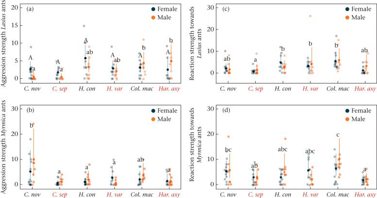

Figure 1. (a, b) Aggression strength (predicted mean ± 95% confidence interval) of the two ant species (a) *[Lasius](https://www.sciencedirect.com/topics/agricultural-and-biological-sciences/lasius)* *neoniger* and (b) *[Myrmica](https://www.sciencedirect.com/topics/agricultural-and-biological-sciences/myrmica)* *americana* confronted with female and male lady beetles. (c, d) Reaction strength (predicted mean ± 95% confidence interval) of lady beetles towards (c) *L. neoniger* and (d) *M. americana* (native species depicted in black: *C. nov* = *Coccinella novemnotata, H. con* = *[Hippodamia convergens](https://www.sciencedirect.com/topics/agricultural-and-biological-sciences/hippodamia-convergens)* and *Col. mac.* = *[Coleomegilla maculata](https://www.sciencedirect.com/topics/agricultural-and-biological-sciences/coleomegilla-maculata)*; non-native lady beetle species depicted in red: *C. sep* = *[Coccinella septempunctata](https://www.sciencedirect.com/topics/agricultural-and-biological-sciences/coccinella-septempunctata)*, *H. var* = *Hippodamia variegata, Har. axy* = *[Harmonia axyridis](https://www.sciencedirect.com/topics/agricultural-and-biological-sciences/harmonia-axyridis)*). Owing to an interactive effect of lady beetle sex in lady beetle–*Lasius neoniger* interactions, we separately tested for differences in ant aggression towards female and male lady beetles. Different letters indicate statistical differences between species based on EMmeans post hoc test with multiple comparison adjustments (Bonferroni correction; *P* ≤ 0.05).

### Behavioural Reactions of Lady Beetles

Reaction strength of lady beetles in interactions with ants differed between lady beetle species (GLMM: ꭕ<sup>2</sup><sub>5, 216</sub> = 34.18, *P* < 0.01) without an effect of sex (ꭕ<sup>2</sup><sub>1, 216</sub> = 2.03, *P* = 0.15) or ant species (ꭕ<sup>2</sup><sub>1, 216</sub> = 1.59, *P* = 0.21). There was no interactive effect of ant species and lady beetle species (ꭕ<sup>2</sup><sub>5, 216</sub> = 9.12, *P* = 0.10), ant species and lady beetle sex (ꭕ<sup>2</sup><sub>1, 216</sub> = 0.14, *P* = 0.71) or lady beetle species and lady beetle sex (ꭕ<sup>2</sup><sub>5, 216</sub> = 2.57, *P* = 0.77) on lady beetle reaction. However, there was a three-way interaction of ant species, lady beetle species and lady beetle sex (ꭕ<sup>2</sup><sub>5, 216</sub> = 12.58, *P* = 0.03) on lady beetle reaction.

In interactions with the ant species *L. neoniger*, lady beetle reaction strength differed interspecifically (GLMM: ꭕ<sup>2</sup><sub>5,106</sub> = 19.28, *P* < 0.01). The non-native *C. septempunctata* showed lower reaction strength towards *L. neoniger* than the native lady beetle species *C. maculata* (EMMpc: *P* < 0.01), *H. convergens* (EMMpc: *P* < 0.05) and the non-native *H. variegata* (EMMpc: *P* = 0.02). The remaining lady beetle species did not differ in their reaction strength towards *L. neoniger* (EMMpc: *P* > 0.14; Fig. 1). There were no differences between lady beetle sexes (GLMM: ꭕ<sup>2</sup><sub>1,106</sub> = 0.32, *P* = 0.57) and no interactive effect of lady beetle species and sex (ꭕ<sup>2</sup><sub>5,106</sub> = 6.11, *P* = 0.30) on reaction strength.

### Chemical Analysis of Lady Beetle Elytra CHCs

The CHC composition on lady beetles' elytra differed between species (pseudo-*F*<sub>5, 34</sub> = 36.92, *P* < 0.01), but not between males and females of the same species (pseudo-*F*<sub>1, 34</sub> = 0.89, *P* = 0.41). Moreover, the CHC composition of all lady beetle species was species specific (pairwise comparison: *P* < 0.04; Fig. 2).

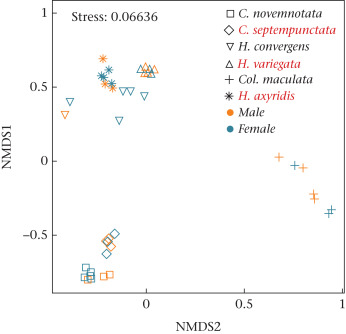

Figure 2. Ordination plot (nonmetric multidimensional scaling (NMDS) with Bray–Curtis dissimilarity) based on the relative abundance of CHCs on elytra of native and non-native lady beetle species (depicted in black and red, respectively). Each individual is represented by one symbol.

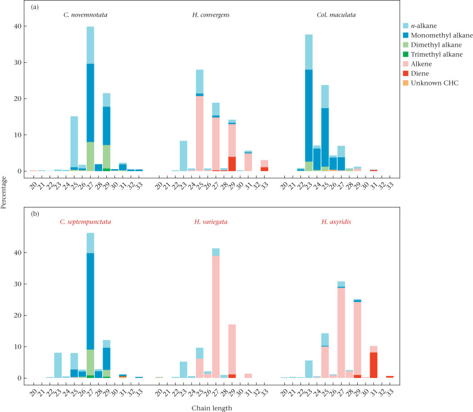

Figure 3. Overview of the CHC profiles of the different lady beetle species. The bars represent the mean relative abundance of CHCs grouped by CHC class (see colour code) and chain length on elytra of native and non-native lady beetle species. (a) Native species: *Coccinella novemnotata, Hippodamia convergens and* *[Coleomegilla maculata](https://www.sciencedirect.com/topics/agricultural-and-biological-sciences/coleomegilla-maculata)*; (b) non-native species: *[Coccinella septempunctata](https://www.sciencedirect.com/topics/agricultural-and-biological-sciences/coccinella-septempunctata)*, *Hippodamia variegata* and *[Harmonia axyridis](https://www.sciencedirect.com/topics/agricultural-and-biological-sciences/harmonia-axyridis)*).

## Discussion

Our findings revealed species-specific CHC compositions and similarities of CHCs between congeneric native and non-native North American lady beetle species. The aggression of both ant species, *L. neoniger* and *M. americana*, towards lady beetles was relatively similar. Overall aggression of ants towards congeneric native and non-native lady beetles of the genera *Coccinella* and *[Hippodamia](https://www.sciencedirect.com/topics/agricultural-and-biological-sciences/hippodamia)* and lady beetles' reaction strength did not differ, with the exception of higher aggression strength of *M. americana* towards the native lady beetle species *C. novemnotata* than towards the non-native *C. septempunctata*. The reaction [behaviour](https://www.sciencedirect.com/topics/neuroscience/behavior-neuroscience) of the native lady beetle *C. maculata* was higher than that of both non-native *H. axyridis* and *C. septempunctata*, despite similar aggression strength of the ant species *M. americana*. Moreover, the reaction behaviour of the native lady beetle *C. maculata* was relatively high compared to that of the non-native *C. septempunctata* in interactions with the ant species *L. neoniger*.

The lady beetle species tested had a species-specific CHC composition on their cuticle (elytra). This agrees with previous studies on the composition of CHCs of lady beetles (Kosaki & Yamaoka, 1996; Magro et al., 2010; Geiselhardt et al., 2011; Bucher et al., 2021). As expected, similarities were visible between substance classes of conspecific native and non-native lady beetle species of the genera *Coccinella* and *Hippodamia*. Interestingly, the non-native *H. axyridis* had similar compound classes to the two *Hippodamia* species (Fig. 3).

Cue similarities between native and non-native species can result in similar interaction outcomes (Sih et al., 2010). In addition to similar cues of *H. axyridis* and the two *Hippodamia* species, our findings show similarities in aggression strength of ants towards the lady beetles *H. axyridis* and the native *H. convergens* and the non-native congeneric *H. variegata*, as well as similar reactions of lady beetles. This is in line with a recent European study, showing that the aggression behaviour of the ant *L. niger* (congeneric to *L. neoniger*) did not differ between the chemically similar non-native *H. axyridis* and the native *H. variegata* (Bucher et al., 2021). Thus, the potential ‘novelty advantage’ of the non-native *H. axyridis*, based on a lack of chemical cue recognition and reduced aggression by native ants, might diminish, due to cue similarities to the native lady beetle *H. convergens*.

Aggression strength of *L. neoniger* ants did not differ between non-native and native *Coccinella* species, nor between both *Hippodamia* species. Here, similar cues of congeneric lady beetle species might explain similar aggression strength of ants (Sih et al., 2010). Surprisingly, *M. americana* was more aggressive towards native *C. novemnotata* than towards the chemically similar non-native *C. septempunctata*, both native and non-native *Hippodamia* species and non-native *H. axyridis*. Thus, in addition to cue similarities, further traits are likely to be involved in lady beetle recognition. Majerus et al. (2007) reviewed traits involved in ant–lady beetle interactions: lady beetles' behaviour, size and defences, as well as ants' size, aggressiveness and density. The multimodality of cues involved in lady beetle–ant interactions might further explain interaction outcomes. Lady beetles have aposematic defence strategies in the form of their red coloration (elytra), [methoxypyrazine](https://www.sciencedirect.com/topics/agricultural-and-biological-sciences/methoxypyrazines) odours and species-specific toxic alkaloids (Bezzerides et al., 2007; Glisan King & Meinwald 1996; Moore et al., 1990; Sloggett et al., 2011), which might elicit aggression and/or repellence in ants. This could partially explain the low aggression behaviour towards some lady beetles. For example, Tursch et al. (1971) isolated the alkaloids coccinelline and precoccinelline from *C. septempunctata* and measured ant repellence. Still, the ant-repelling properties of species-specific alkaloids in other lady beetle species require further research.

Interestingly, in Europe the aggression strength of *L. niger* (congeneric to *L. neoniger*) was lower towards the invasive *H. axyridis* than towards *C. septempunctata* (Bucher et al., 2021). Similar to ant–lady beetle interactions in Europe, we found differences in aggression behaviour of the congeneric *L. neoniger* towards *H. axyridis* and *C. septempunctata* (and *C. novemnotata*), but only between male beetles. This might be explained by sex-specific differences. For example, a study of the aposematic system in *H. convergens* showed that the red coloration of lady beetles, a visual cue for unpalatability, is positively correlated with the amount of toxic alkaloids in females. In contrast, the amount of methoxypyrazine and alkaloids was negatively correlated, regardless of lady beetle sex (Wheeler et al., 2015). However, we did not investigate chemical or visual differences within species, which could contribute to a better understanding of sex-specific differences in ant aggression. Interestingly, *C. septempunctata* produces 2-isopropyl-3-methoxy-pyrazine, found to be involved in intraspecific attraction (Al Abassi et al., 1998) and serves in combination with the cuticular hydrocarbon n-C23, as [aggregation pheromone](https://www.sciencedirect.com/topics/agricultural-and-biological-sciences/aggregation-pheromone) in *H. convergens* (Wheeler & Cardé, 2014). The methoxypyrazines of coccinellids underlie semiochemical parsimony by both warding off predators and serving as an aggregation pheromone (Al Abassi et al., 1998). Here, the malodorous methoxypyrazines (Wheeler et al., 2015) could function as an odour cue, triggering aggression and/or repellence of ants. Overall, the differences in ant aggression could be explained by differences in synergistic effects/the interaction of multiple cues used to identify a potential threat (or competitor), since some defence traits are species-specific (and/or sex-specific), while others are common to lady beetles.

Furthermore, the defensive strategies of lady beetles might also influence lady beetles' reaction strength; an efficient defence strategy, such as ant repellence, might be in line with tolerance towards ant attacks. Based on our findings, the native *C. maculata* shows relatively high reaction strength compared to non-native lady beetles, despite similarities in strength of ant aggression, indicating low ant tolerance. Additionally, our results show low reaction strength of both non-native *C. septempunctata* and *H. axyridis*; however, ant aggression was similarly low, making it rather difficult to suggest ant tolerance from our experiments. In Europe, Bucher et al. (2021) demonstrated that the reaction of the native *C. septempunctata* was higher towards *L. niger* and *[Myrmica rubra](https://www.sciencedirect.com/topics/agricultural-and-biological-sciences/myrmica-rubra)* than that of the non-native *H. axyridis*, despite similar aggression strength of *M. rubra*, but a comparatively lower aggression strength of. *L. niger* towards *H. axyridis*. This could indicate a lower ant tolerance of native *C. septempuncta* in Europe compared to non-native *H. axyridis*. Interestingly, *C. septempunctata* coexists with *[Formica rufa](https://www.sciencedirect.com/topics/agricultural-and-biological-sciences/formica-rufa)* and consequently has shown intermediate ant tolerance in previous studies in its native European range which could be explained by the species-specific chemical protection of *C. septempunctata* to deter predators (Bhatkar, 1982; Sloggett & Majerus, 2000; Tursch et al., 1971). In addition, a higher tolerance of *H. axyridis* towards the ant species *[Solenopsis invicta](https://www.sciencedirect.com/topics/agricultural-and-biological-sciences/solenopsis-invicta)* compared to that of *H. convergens*, has been documented (Dutcher et al., 1999). Ant–lady beetle interference over aphids mostly occurs when food is scarce; therefore, ant-tolerant lady beetle species could have a facilitated access to aphids compared to less tolerant lady beetles, in times of food scarcity. The ‘dietary shift’ to ant-tended aphids during a shortage of resources could be explained by an essential need for sufficient resources to survive overwintering (Sloggett & Majerus, 2000). According to a field study by Sloggett and Majerus (2000) interspecific differences between lady beetle species in *F. rufa* tending aphid colonies occurred not only during aphid scarcity, but also during periods of aphid abundance. Both non-native *C. septempunctata* and *H. axyridis* are among the most voracious species tested (Ünlü, Obrycki, et al., 2020; Ünlü, Terlau, et al. 2020), suggesting a high predation pressure on ant-tended aphids under natural conditions, if both species show ant tolerance. Thus, the ant tolerance of non-native lady beetles might enable them to feed on ant-tended colonies, throughout the season. Although the dietary flexibility of native lady beetles, such as *C. maculata* might include other available food resources during times of aphid scarcity (Evans, 2009), it is possible that the dietary needs of larger non-native lady beetle species could be a crucial driver of mutual competition on ant-tended aphids. Future field studies on ant–lady beetle–aphid interactions involving *H. axyridis* and *C. septempunctata* in the native and non-native range might shed light on ant tolerance and competitive advantages of non-native lady beetle species (Pell et al., 2008). Additionally, species interactions in the field underlie spatial and temporal variation and differ between environments (Poisot et al. 2012, 2015). Here, the interactions between the tested native lady beetle and ant species, which are relatively common across agricultural fields (Gordon, 1985; Helms IV et al., 2021), could vary in the frequency of encounters due to missing spatial and/or temporal co-occurrence. This raises intriguing questions regarding the competition of various lady beetle species on aphid-tended resources in the field and should be addressed in the future.

### Conclusion

In contrast to our hypothesis, the aggressiveness of ants and the reaction of lady beetles did not reflect the pattern of cue similarity between lady beetle species. This tentatively suggests that additional cues are likely to be involved in lady beetle recognition. Our chemical analyses demonstrated that lady beetles have species-specific chemical cues and that species of the same genus (*Coccinella* and *Hippodamia*) share similar CHCs or CHC classes. However, species of other genera can also be similar in terms of their CHCs. Therefore, taxonomic relationships should be taken with caution when predicting the novelty character of a non-native species. Despite similar aggression, a stronger response of native lady beetles, such as *Col. maculata* compared to non-native lady beetles, might indicate a competition disadvantage when feeding on ant-tended aphids. Larger sets including diverse species cues might further help to explain and predict novel species interactions.

## Author Contributions

Conceptualization: R.B. Methodology: R.B., F.M., A.G.U. Formal analysis and investigation: A.G.U. Writing—original draft: A.G.U. Writing—review & editing: A.G.U., J.J.O., F.M., R.B. Funding acquisition: R.B. Resources: R.B., J.J.O., F.M. Supervision: R.B., J.J.O., F.M.

## Data Availability

Data are available at Mendeley Data https://doi.org/10.17632/45yv7ymzf5.1.

## Declaration of Interest

The authors have no conflict of interest to declare.

## Acknowledgments

We thank Nathan Mercer for the maintenance and collecting of insects. We are grateful to Kenneth Haynes for his assistance and providing laboratory space. We thank the Department of Entomology at the University of Kentucky and the Institute of Organismic and [Molecular Evolution](https://www.sciencedirect.com/topics/agricultural-and-biological-sciences/molecular-evolution) at the Johannes Gutenberg-Universität Mainz for the use of technical equipment. Partial funding for the portion of this research conducted at the University of Kentucky was provided by the Bobby C. Pass Research Professorship. The study was funded by the Deutsche Forschungsgemeinschaft (DFG) under grant number BU3382/1-1 to RB.

## References

1. Al Abassi et al., 1998

   S. Al Abassi, M.A. Birkett, J. Pettersson, J.A. Pickett, C.M. Woodcock

   Ladybird beetle odour identified and found to be responsible for attraction between adults

   Cellular and Molecular Life Sciences, 54 (1998), pp. 876-879

   [View in Scopus](https://www.scopus.com/inward/record.url?eid=2-s2.0-0031670809&partnerID=10&rel=R3.0.0)Google Scholar
2. Alyokhin and Sewell, 2004

   A. Alyokhin, G. Sewell

   Changes in a lady beetle community following the establishment of three alien species

   Biological Invasions, 6 (2004), pp. 463-471

   [View in Scopus](https://www.scopus.com/inward/record.url?eid=2-s2.0-4544336117&partnerID=10&rel=R3.0.0)Google Scholar
3. Banks and Dickman, 2007

   P.B. Banks, C.R. Dickman

   Alien predation and the effects of multiple levels of prey naiveté

   Trends in Ecology & Evolution, 5 (2007), pp. 229-230

   [View PDF](https://www.sciencedirect.com/science/article/pii/S0169534707000407/pdfft?md5=83940e15f1fa81d53162657539d1d200&pid=1-s2.0-S0169534707000407-main.pdf)[View article](https://www.sciencedirect.com/science/article/pii/S0169534707000407)[View in Scopus](https://www.scopus.com/inward/record.url?eid=2-s2.0-34247150591&partnerID=10&rel=R3.0.0)[Google Scholar](https://scholar.google.com/scholar_lookup?title=Alien%20predation%20and%20the%20effects%20of%20multiple%20levels%20of%20prey%20naivet%C3%A9&publication_year=2007&author=P.B.%20Banks&author=C.R.%20Dickman)
4. Bezzerides et al., 2007

   A.L. Bezzerides, K.J. McGraw, R.S. Parker, J. Husseini

   Elytra color as a signal of chemical defense in the Asian ladybird beetle *Harmonia axyridis*

   Behavioral Ecology and Sociobiology, 61 (9) (2007), pp. 1401-1408

   [CrossRef](https://doi.org/10.1007/s00265-007-0371-9)[View in Scopus](https://www.scopus.com/inward/record.url?eid=2-s2.0-34250665512&partnerID=10&rel=R3.0.0)Google Scholar
5. Bhatkar, 1982

   A.P. Bhatkar

   Orientation and defense of ladybeetles (Coleophera: Coccinellidae), following ant trail in search of aphids

   Folia Entomologica Mexicana, 53 (1982), pp. 75-85

   [Google Scholar](https://scholar.google.com/scholar?q=Orientation%20and%20defense%20of%20ladybeetles%20,%20following%20ant%20trail%20in%20search%20of%20aphids)
6. Binz et al., 2014

   H. Binz, S. Foitzik, F. Staab, F. Menzel

   The chemistry of competition: Exploitation of heterospecific cues depends on the dominance rank in the community

   Animal Behaviour, 94 (2014), pp. 45-53

   [View PDF](https://www.sciencedirect.com/science/article/pii/S0003347214002449/pdfft?md5=399f958051d568c85a51d5d8351103e0&pid=1-s2.0-S0003347214002449-main.pdf)[View article](https://www.sciencedirect.com/science/article/pii/S0003347214002449)[View in Scopus](https://www.scopus.com/inward/record.url?eid=2-s2.0-84902993978&partnerID=10&rel=R3.0.0)Google Scholar
7. Blackwell, 2005

   G.L. Blackwell

   Another world: The composition and consequences of the introduced mammal fauna of New Zealand

   Australian Zoologist, 33 (2005), pp. 108-118

   [View in Scopus](https://www.scopus.com/inward/record.url?eid=2-s2.0-24144476287&partnerID=10&rel=R3.0.0)Google Scholar
8. Bond and Slingsby, 1984

   W.J. Bond, P. Slingsby

   Collapse of an ant-plant mutualism: The Argentine ant (*Iridomyrmex humilis*) and Myrmecochorous Proteaceae

   Ecology, 65 (1984), pp. 1031-1037

   [CrossRef](https://doi.org/10.2307/1938311)[View in Scopus](https://www.scopus.com/inward/record.url?eid=2-s2.0-0021554910&partnerID=10&rel=R3.0.0)[Google Scholar](https://scholar.google.com/scholar?q=Collapse%20of%20an%20ant-plant%20mutualism:%20The%20Argentine%20ant%20%20and%20Myrmecochorous%20Proteaceae)
9. Bradley, 1973

   G.A. Bradley

   Effect of *Formica obscuripes* (Hymenoptera: Formicidae) on the predator–prey relationship between *Hyperaspis congressis* (Coleoptera: Coccinellidae) and *Toumeyella numismaticum* (Homoptera: Coccidae)

   Canadian Entomologist, 105 (1973), pp. 1113-1118

   [View in Scopus](https://www.scopus.com/inward/record.url?eid=2-s2.0-0000822853&partnerID=10&rel=R3.0.0)[Google Scholar](https://scholar.google.com/scholar?q=Effect%20of%20Formica%20obscuripes%20%20on%20the%20predatorprey%20relationship%20between%20Hyperaspis%20congressis%20%20and%20Toumeyella%20numismaticum)
10. Brooks et al., 2017

    M.E. Brooks, K. Kristensen, K.J. van Benthem, A. Magnusson, C.W. Berg, A. Nielsen, H.J. Skaug, M. Mächler, B.M. Bolker

    glmmTMB balances speed and flexibility among packages for zero-inflated generalized linear mixed modeling

    R Journal, 9 (2017), pp. 378-400

    [CrossRef](https://doi.org/10.32614/rj-2017-066)[View in Scopus](https://www.scopus.com/inward/record.url?eid=2-s2.0-85041212403&partnerID=10&rel=R3.0.0)Google Scholar
11. Bucher et al., 2021

    R. Bucher, L.M. Japke, A.G. Ünlü, F. Menzel

    Interactions of ants with native and invasive lady beetles and the role of chemical cues in intraguild interference

    Chemoecology (2021), pp. 1-12

    [View in Scopus](https://www.scopus.com/inward/record.url?eid=2-s2.0-85099337953&partnerID=10&rel=R3.0.0)Google Scholar
12. Carthey and Banks, 2014

    A.J. Carthey, P.B. Banks

    Naïveté in novel ecological interactions: Lessons from theory and experimental evidence

    Biological Reviews, 89 (2014), pp. 932-949

    [CrossRef](https://doi.org/10.1111/brv.12087)[View in Scopus](https://www.scopus.com/inward/record.url?eid=2-s2.0-84925282274&partnerID=10&rel=R3.0.0)Google Scholar
13. Carthey et al., 2017

    A.J. Carthey, M.P. Bucknall, K. Wierucka, P.B. Banks

    Novel predators emit novel cues: A mechanism for prey naivety towards alien predators

    Scientific Reports, 7 (2017), pp. 1-9

    Google Scholar
14. Cox and Lima, 2006

    J.G. Cox, S.L. Lima

    Naivete and an aquatic-terrestrial dichotomy in the effects of introduced predators

    Trends in Ecology & Evolution, 21 (2006), pp. 674-680

    [View PDF](https://www.sciencedirect.com/science/article/pii/S0169534706002412/pdfft?md5=54c762f74b03b9b08800f3a4fc957a7c&pid=1-s2.0-S0169534706002412-main.pdf)[View article](https://www.sciencedirect.com/science/article/pii/S0169534706002412)[View in Scopus](https://www.scopus.com/inward/record.url?eid=2-s2.0-33750974149&partnerID=10&rel=R3.0.0)Google Scholar
15. Dettner and Liepert, 1994

    K. Dettner, C. Liepert

    Chemical mimicry and camouflage

    Annual Review of Entomology, 39 (1994), pp. 129-154

    [CrossRef](https://doi.org/10.1146/annurev.en.39.010194.001021)[View in Scopus](https://www.scopus.com/inward/record.url?eid=2-s2.0-0028565353&partnerID=10&rel=R3.0.0)[Google Scholar](https://scholar.google.com/scholar_lookup?title=Chemical%20mimicry%20and%20camouflage&publication_year=1994&author=K.%20Dettner&author=C.%20Liepert)
16. Dutcher et al., 1999

    J.D. Dutcher, P.M. Estes, M.J. Dutcher

    Interactions in entomology: Aphids, aphidophaga and ants in pecan orchards

    Journal of Entomological Science, 34 (1999), pp. 40-56

    [CrossRef](https://doi.org/10.18474/0749-8004-34.1.40)[View in Scopus](https://www.scopus.com/inward/record.url?eid=2-s2.0-0032928550&partnerID=10&rel=R3.0.0)Google Scholar
17. Eccard and Ylönen, 2002

    J.A. Eccard, H. Ylönen

    Direct interference or indirect exploitation? An experimental study of fitness costs of interspecific competition in voles

    Oikos, 99 (2002), pp. 580-590

    [CrossRef](https://doi.org/10.1034/j.1600-0706.2002.11833.x)[View in Scopus](https://www.scopus.com/inward/record.url?eid=2-s2.0-0036957394&partnerID=10&rel=R3.0.0)[Google Scholar](https://scholar.google.com/scholar?q=Direct%20interference%20or%20indirect%20exploitation%20An%20experimental%20study%20of%20fitness%20costs%20of%20interspecific%20competition%20in%20voles)
18. Elliott et al., 1996

    N. Elliott, R. Kieckhefer, W. Kauffman

    Effects of an invading coccinellid on native coccinellids in an agricultural landscape

    Oecologia, 105 (1996), pp. 537-544

    [View in Scopus](https://www.scopus.com/inward/record.url?eid=2-s2.0-0030023886&partnerID=10&rel=R3.0.0)Google Scholar
19. Evans, 2000

    E.W. Evans

    Morphology of invasion: Body size patterns associated with establishment of *Coccinella septempunctata* (Coleoptera: Coccinellidae) in western North America

    European Journal of Entomology, 97 (2000), pp. 469-474

    [CrossRef](https://doi.org/10.14411/eje.2000.072)[View in Scopus](https://www.scopus.com/inward/record.url?eid=2-s2.0-0034489632&partnerID=10&rel=R3.0.0)[Google Scholar](https://scholar.google.com/scholar?q=Morphology%20of%20invasion:%20Body%20size%20patterns%20associated%20with%20establishment%20of%20Coccinella%20septempunctata%20%20in%20western%20North%20America)
20. Evans, 2009

    E.W. Evans

    Lady beetles as predators of insects other than Hemiptera

    Biological Control, 51 (2009), pp. 255-267

    [View PDF](https://www.sciencedirect.com/science/article/pii/S1049964409001388/pdfft?md5=8c2643b14fa87326ad02a68cfa3de2d5&pid=1-s2.0-S1049964409001388-main.pdf)[View article](https://www.sciencedirect.com/science/article/pii/S1049964409001388)[View in Scopus](https://www.scopus.com/inward/record.url?eid=2-s2.0-70349279923&partnerID=10&rel=R3.0.0)[Google Scholar](https://scholar.google.com/scholar_lookup?title=Lady%20beetles%20as%20predators%20of%20insects%20other%20than%20Hemiptera&publication_year=2009&author=E.W.%20Evans)
21. Finlayson et al., 2009

    C.J. Finlayson, A.V. Alyokhin, E.W. Porter

    Interactions of native and non-native lady beetle species (Coleoptera: Coccinellidae) with aphid-tending ants in laboratory arenas

    Environmental Entomology, 38 (2009), pp. 846-855

    [CrossRef](https://doi.org/10.1603/022.038.0338)[View in Scopus](https://www.scopus.com/inward/record.url?eid=2-s2.0-68049083501&partnerID=10&rel=R3.0.0)[Google Scholar](https://scholar.google.com/scholar?q=Interactions%20of%20native%20and%20non-native%20lady%20beetle%20species%20%20with%20aphid-tending%20ants%20in%20laboratory%20arenas)
22. Fox and Weisberg, 2019

    J. Fox, S. Weisberg

    An {R} companion to applied regression

    (3rd ed.), Sage (2019)

    https://socialsciences.mcmaster.ca/jfox/Books/Companion/

    [Google Scholar](https://scholar.google.com/scholar?q=An%20R%20companion%20to%20applied%20regression)
23. Geiselhardt et al., 2011

    S.F. Geiselhardt, S. Geiselhardt, K. Peschke

    Congruence of epicuticular hydrocarbons and tarsal secretions as a principle in beetles

    Chemoecology, 21 (2011), pp. 181-186

    [CrossRef](https://doi.org/10.1007/s00049-011-0077-3)[View in Scopus](https://www.scopus.com/inward/record.url?eid=2-s2.0-85027953195&partnerID=10&rel=R3.0.0)Google Scholar
24. Glisan King and Meinwald, 1996

    A. Glisan King, J. Meinwald

    Review of the defensive chemistry of coccinellids

    Chemical Reviews, 96 (1996), pp. 1105-1122

    [Google Scholar](https://scholar.google.com/scholar_lookup?title=Review%20of%20the%20defensive%20chemistry%20of%20coccinellids&publication_year=1996&author=A.%20Glisan%20King&author=J.%20Meinwald)
25. Gordon, 1985

    R.D. Gordon

    The Coccinellidae (Coleoptera) of America north of Mexico

    Journal of the New York Entomological Society, 93 (1985), pp. 1-912

    [Google Scholar](https://scholar.google.com/scholar?q=The%20Coccinellidae%20%20of%20America%20north%20of%20Mexico)
26. Greene and Gordon, 2003

    M.J. Greene, D.M. Gordon

    Cuticular hydrocarbons inform task decisions

    Nature, 423 (2003)

    32–32

    [Google Scholar](https://scholar.google.com/scholar_lookup?title=Cuticular%20hydrocarbons%20inform%20task%20decisions&publication_year=2003&author=M.J.%20Greene&author=D.M.%20Gordon)
27. Harmon et al., 2007

    J.P. Harmon, E. Stephens, J. Losey

    The decline of native coccinellids (Coleoptera: Coccinellidae) in the United States and Canada

    Journal of Insect Conservation, 11 (2007), pp. 85-94

    [Google Scholar](https://scholar.google.com/scholar?q=The%20decline%20of%20native%20coccinellids%20%20in%20the%20United%20States%20and%20Canada)
28. Hartig, 2021

    F. Hartig

    DHARMa: Residual diagnostics for hierarchical (multi-level/mixed) regression models

    (2021)

    R package version 0.4.3

    [https://CRAN.R-project.org/package=DHARMa](https://cran.r-project.org/package=DHARMa)

    [Google Scholar](https://scholar.google.com/scholar?q=DHARMa:%20Residual%20diagnostics%20for%20hierarchical%20%20regression%20models)
29. Helms IV et al., 2021

    J.A. Helms IV, J. Smith, S. Clark, K. Knupp, N.M. Haddad

    Ant communities and ecosystem services in organic versus conventional agriculture in the US Corn Belt

    Environmental Entomology, 50 (2021), pp. 1276-1285

    [CrossRef](https://doi.org/10.1093/ee/nvab105)[View in Scopus](https://www.scopus.com/inward/record.url?eid=2-s2.0-85122841154&partnerID=10&rel=R3.0.0)Google Scholar
30. Hervé, 2021

    M. Hervé

    RVAideMemoire: Testing and plotting procedures for biostatistics

    (2021)

    R package version 0.9-81

    [https://CRAN.R-project.org/package=RVAideMemoire](https://cran.r-project.org/package=RVAideMemoire)

    [Google Scholar](https://scholar.google.com/scholar_lookup?title=RVAideMemoire%3A%20Testing%20and%20plotting%20procedures%20for%20biostatistics&publication_year=2021&author=M.%20Herv%C3%A9)
31. Hoki et al., 2014

    E. Hoki, J. Losey, T.A. Ugine

    Comparing the consumptive and non-consumptive effects of a native and introduced lady beetle on pea aphids (*Acyrthosiphon pisum*)

    Biological Control, 70 (2014), pp. 78-84

    [View PDF](https://www.sciencedirect.com/science/article/pii/S1049964413002934/pdfft?md5=168d00fb4d90c01b932f78c522b58cbc&pid=1-s2.0-S1049964413002934-main.pdf)[View article](https://www.sciencedirect.com/science/article/pii/S1049964413002934)[View in Scopus](https://www.scopus.com/inward/record.url?eid=2-s2.0-84892653571&partnerID=10&rel=R3.0.0)[Google Scholar](https://scholar.google.com/scholar?q=Comparing%20the%20consumptive%20and%20non-consumptive%20effects%20of%20a%20native%20and%20introduced%20lady%20beetle%20on%20pea%20aphids)
32. Human and Gordon, 1997

    K.G. Human, D.M. Gordon

    Effects of Argentine ants on invertebrate biodiversity in northern California

    Conservation Biology, 11 (1997), pp. 1242-1248

    [View in Scopus](https://www.scopus.com/inward/record.url?eid=2-s2.0-0031413692&partnerID=10&rel=R3.0.0)[Google Scholar](https://scholar.google.com/scholar_lookup?title=Effects%20of%20Argentine%20ants%20on%20invertebrate%20biodiversity%20in%20northern%20California&publication_year=1997&author=K.G.%20Human&author=D.M.%20Gordon)
33. Kajita and Evans, 2010

    Y. Kajita, E.W. Evans

    Relationships of body size, fecundity, and invasion success among predatory lady beetles (Coleoptera: Coccinellidae) inhabiting alfalfa fields

    Annals of the Entomological Society of America, 103 (2010), pp. 750-756

    [View in Scopus](https://www.scopus.com/inward/record.url?eid=2-s2.0-77956159182&partnerID=10&rel=R3.0.0)[Google Scholar](https://scholar.google.com/scholar?q=Relationships%20of%20body%20size,%20fecundity,%20and%20invasion%20success%20among%20predatory%20lady%20beetles%20%20inhabiting%20alfalfa%20fields)
34. Kosaki and Yamaoka, 1996

    A. Kosaki, R. Yamaoka

    Chemical composition of footprints and cuticula lipids of three species of lady beetles

    Japanese Journal of Applied Entomology and Zoology, 40 (1996), pp. 47-53

    [CrossRef](https://doi.org/10.1303/jjaez.40.47)[View in Scopus](https://www.scopus.com/inward/record.url?eid=2-s2.0-0342687690&partnerID=10&rel=R3.0.0)Google Scholar
35. Lenth, 2021

    R.V. Lenth

    emmeans: Estimated marginal means, aka least-squares means

    (2021)

    R package version 1.6.2-1

    [https://CRAN.R-project.org/package=emmeans](https://cran.r-project.org/package=emmeans)

    [Google Scholar](https://scholar.google.com/scholar_lookup?title=emmeans%3A%20Estimated%20marginal%20means%2C%20aka%20least-squares%20means&publication_year=2021&author=R.V.%20Lenth)
36. Losey and Denno, 1998

    J.E. Losey, R.F. Denno

    Positive predator-predator interactions: Enhanced predation rates and synergistic suppression of aphid populations

    Ecology, 79 (1998), pp. 2143-2152

    [View in Scopus](https://www.scopus.com/inward/record.url?eid=2-s2.0-0031669778&partnerID=10&rel=R3.0.0)Google Scholar
37. Lucas, 2013

    É. Lucas

    Intraguild predation among aphidophagous predators

    European Journal of Entomology, 102 (2013), pp. 351-364

    [Google Scholar](https://scholar.google.com/scholar_lookup?title=Intraguild%20predation%20among%20aphidophagous%20predators&publication_year=2013&author=%C3%89.%20Lucas)
38. Magro et al., 2010

    A. Magro, C. Ducamp, F. Ramon-Portugal, E. Lecompte, B. Crouau-Roy, A.F.G. Dixon, J.L. Hemptinne

    Oviposition deterring infochemicals in ladybirds: The role of phylogeny

    Evolutionary Ecology, 24 (2010), pp. 251-271

    [CrossRef](https://doi.org/10.1007/s10682-009-9304-6)[View in Scopus](https://www.scopus.com/inward/record.url?eid=2-s2.0-75549088985&partnerID=10&rel=R3.0.0)Google Scholar
39. Majerus et al., 2007

    M.E. Majerus, J.J. Sloggett, J.F. Godeau, J.L. Hemptinne

    Interactions between ants and aphidophagous and coccidophagous ladybirds

    Population Ecology, 49 (2007), pp. 15-27

    [CrossRef](https://doi.org/10.1007/s10144-006-0021-5)[View in Scopus](https://www.scopus.com/inward/record.url?eid=2-s2.0-33846062157&partnerID=10&rel=R3.0.0)Google Scholar
40. Menzel et al., 2017

    F. Menzel, B.B. Blaimer, T. Schmitt

    How do cuticular hydrocarbons evolve? Physiological constraints and climatic and biotic selection pressures act on a complex functional trait

    Proceedings of the Royal Society B: Biological Sciences, 284 (2017), Article 20161727

    [CrossRef](https://doi.org/10.1098/rspb.2016.1727)[View in Scopus](https://www.scopus.com/inward/record.url?eid=2-s2.0-85015332568&partnerID=10&rel=R3.0.0)Google Scholar
41. Michaud, 2002

    J.P. Michaud

    Invasion of the Florida citrus ecosystem by *Harmonia axyridis* (Coleoptera: Coccinellidae) and asymmetric competition with a native species, *Cycloneda sanguinea*

    Environmental Entomology, 31 (2002), pp. 827-835

    [View in Scopus](https://www.scopus.com/inward/record.url?eid=2-s2.0-0036801565&partnerID=10&rel=R3.0.0)[Google Scholar](https://scholar.google.com/scholar?q=Invasion%20of%20the%20Florida%20citrus%20ecosystem%20by%20Harmonia%20axyridis%20%20and%20asymmetric%20competition%20with%20a%20native%20species,%20Cycloneda%20sanguinea)
42. Moore et al., 1990

    B.P. Moore, W.V. Brown, M. Rothschild

    Methylalkylpyrazines in aposematic insects, their hostplants and mimics

    Chemoecology, 1 (1990), pp. 43-51

    [View in Scopus](https://www.scopus.com/inward/record.url?eid=2-s2.0-0002735443&partnerID=10&rel=R3.0.0)Google Scholar
43. Moser and Obrycki, 2009

    S.E. Moser, J.J. Obrycki

    Competition and intraguild predation among three species of coccinellids (Coleoptera: Coccinellidae)

    Annals of the Entomological Society of America, 102 (2009), pp. 419-425

    [CrossRef](https://doi.org/10.1603/008.102.0310)[View in Scopus](https://www.scopus.com/inward/record.url?eid=2-s2.0-67649823749&partnerID=10&rel=R3.0.0)[Google Scholar](https://scholar.google.com/scholar?q=Competition%20and%20intraguild%20predation%20among%20three%20species%20of%20coccinellids)
44. Ninkovic et al., 2013

    V. Ninkovic, Y. Feng, U. Olsson, J. Pettersson

    Ladybird footprints induce aphid avoidance behavior

    Biological Control, 65 (2013), pp. 63-71

    [View PDF](https://www.sciencedirect.com/science/article/pii/S1049964412001430/pdfft?md5=5db341247460c1976bca53ba47f8e33f&pid=1-s2.0-S1049964412001430-main.pdf)[View article](https://www.sciencedirect.com/science/article/pii/S1049964412001430)[View in Scopus](https://www.scopus.com/inward/record.url?eid=2-s2.0-84875672311&partnerID=10&rel=R3.0.0)Google Scholar
45. Obrycki et al., 1998

    J.J. Obrycki, K.L. Giles, A.M. Ormord

    Interactions between an introduced and indigenous coccinellid species at different prey densities

    Oecologia, 117 (1998), pp. 279-285

    [View in Scopus](https://www.scopus.com/inward/record.url?eid=2-s2.0-0032405927&partnerID=10&rel=R3.0.0)Google Scholar
46. Oksanen et al., 2020

    J. Oksanen, F.G. Blanchet, M. Friendly, R. Kindt, P. Legendre, D. McGlinn, P.R. Minchin, R.B. O'Hara, G.L. Simpson, P. Solymos, M.H.M. Stevens, E. Szoecs, H. Wagner

    vegan: Community ecology package

    (2020)

    R package version 2.5-7

    [https://CRAN.R-project.org/package=vegan](https://cran.r-project.org/package=vegan)

    Google Scholar
47. Pasteels, 2007

    J.M. Pasteels

    Chemical defence, offence and alliance in ants-aphids-ladybirds relationships

    Population Ecology, 49 (2007), pp. 5-14

    [CrossRef](https://doi.org/10.1007/s10144-006-0023-3)[View in Scopus](https://www.scopus.com/inward/record.url?eid=2-s2.0-33846046486&partnerID=10&rel=R3.0.0)[Google Scholar](https://scholar.google.com/scholar_lookup?title=Chemical%20defence%2C%20offence%20and%20alliance%20in%20ants-aphids-ladybirds%20relationships&publication_year=2007&author=J.M.%20Pasteels)
48. Pell et al., 2008

    J.K. Pell, J. Baverstock, H.E. Roy, R.L. Ware, M.E. Majerus

    Intraguild predation involving *Harmonia axyridis*: A review of current knowledge and future perspectives

    BioControl, 53 (2008), pp. 147-168

    Google Scholar
49. Poisot et al., 2012

    T. Poisot, E. Canard, D. Mouillot, N. Mouquet, D. Gravel

    The dissimilarity of species interaction networks

    Ecology Letters, 15 (2012), pp. 1353-1361

    [CrossRef](https://doi.org/10.1111/ele.12002)[View in Scopus](https://www.scopus.com/inward/record.url?eid=2-s2.0-84867479070&partnerID=10&rel=R3.0.0)Google Scholar
50. Poisot et al., 2015

    T. Poisot, D.B. Stouffer, D. Gravel

    Beyond species: Why ecological interaction networks vary through space and time

    Oikos, 124 (2015), pp. 243-251

    [CrossRef](https://doi.org/10.1111/oik.01719)[View in Scopus](https://www.scopus.com/inward/record.url?eid=2-s2.0-84923362158&partnerID=10&rel=R3.0.0)Google Scholar
51. Polis et al., 1989

    G.A. Polis, C.A. Myers, R.D. Holt

    The ecology and evolution of intraguild predation: Potential competitors that eat each other

    Annual Review of Ecology and Systematics, 20 (1989), pp. 297-330

    [CrossRef](https://doi.org/10.1146/annurev.es.20.110189.001501)[View in Scopus](https://www.scopus.com/inward/record.url?eid=2-s2.0-0024870634&partnerID=10&rel=R3.0.0)Google Scholar
52. Putman and Putman, 1994

    R.J. Putman, R. Putman

    Community ecology

    Chapman & Hall (1994)

    [Google Scholar](https://scholar.google.com/scholar_lookup?title=Community%20ecology&publication_year=1994&author=R.J.%20Putman&author=R.%20Putman)
53. R Development Core Team, 2018

    R Development Core Team

    R: A language and environment for statistical computing

    R Foundation for Statistical Computing (2018)

    [https://www.R-project.org/](https://www.r-project.org/)

    [Google Scholar](https://scholar.google.com/scholar_lookup?title=R%3A%20A%20language%20and%20environment%20for%20statistical%20computing&publication_year=2018&author=R%20Development%20Core%20Team)
54. Rosenheim et al., 1995

    J.A. Rosenheim, H.K. Kaya, L.E. Ehler, J.J. Marois, B.A. Jaffee

    Intraguild predation among biological-control agents: Theory and evidence

    Biological Control, 5 (1995), pp. 303-335

    [View PDF](https://www.sciencedirect.com/science/article/pii/S1049964485710389/pdf?md5=842125a2057e34d8fb291dc95811a11f&pid=1-s2.0-S1049964485710389-main.pdf)[View article](https://www.sciencedirect.com/science/article/pii/S1049964485710389)[View in Scopus](https://www.scopus.com/inward/record.url?eid=2-s2.0-85032068610&partnerID=10&rel=R3.0.0)Google Scholar
55. Roy et al., 2016

    H.E. Roy, P.M.J. Brown, T. Adriaens, N. Berkvens, I. Borges, S. Clusella-Trullas, R.F. Comont, P. De Clercq, R. Eschen, A. Estoup, E.W. Evans, B. Facon, M.M. Gardiner, A. Gil, A.A. Grez, T. Guillemaud, D. Haelewaters, A. Herz, A. Honek, …, Z. Zhao

    The harlequin ladybird, *Harmonia axyridis*: Global perspectives on invasion history and ecology

    Biological Invasions, 18 (2016), pp. 997-1044

    [CrossRef](https://doi.org/10.1007/s10530-016-1077-6)[View in Scopus](https://www.scopus.com/inward/record.url?eid=2-s2.0-84961798330&partnerID=10&rel=R3.0.0)Google Scholar
56. Sanders et al., 2003

    N.J. Sanders, N.J. Gotelli, N.E. Heller, D.M. Gordon

    Community disassembly by an invasive species

    Proceedings of the National Academy of Sciences, 100 (2003), pp. 2474-2477

    [View in Scopus](https://www.scopus.com/inward/record.url?eid=2-s2.0-0037418176&partnerID=10&rel=R3.0.0)Google Scholar
57. Sih et al., 2010

    A. Sih, D.I. Bolnick, B. Luttbeg, J.L. Orrock, S.D. Peacor, L.M. Pintor, E. Preisser, J.S. Rehage, J.R. Vonesh

    Predator-prey naïveté, antipredator behavior, and the ecology of predator invasions

    Oikos, 119 (2010), pp. 610-621

    [CrossRef](https://doi.org/10.1111/j.1600-0706.2009.18039.x)[View in Scopus](https://www.scopus.com/inward/record.url?eid=2-s2.0-77951118799&partnerID=10&rel=R3.0.0)Google Scholar
58. Sih et al., 1998

    A. Sih, G. Englund, D. Wooster

    Emergent impacts of multiple predators on prey

    Trends in Ecology & Evolution, 13 (1998), pp. 350-355

    [View PDF](https://www.sciencedirect.com/science/article/pii/S0169534798014372/pdfft?md5=ec70cb542179fe626d683ef662acb58e&pid=1-s2.0-S0169534798014372-main.pdf)[View article](https://www.sciencedirect.com/science/article/pii/S0169534798014372)[View in Scopus](https://www.scopus.com/inward/record.url?eid=2-s2.0-0031880532&partnerID=10&rel=R3.0.0)[Google Scholar](https://scholar.google.com/scholar_lookup?title=Emergent%20impacts%20of%20multiple%20predators%20on%20prey&publication_year=1998&author=A.%20Sih&author=G.%20Englund&author=D.%20Wooster)
59. Sloggett et al., 2011

    J.J. Sloggett, A. Magro, F.J. Verheggen, J.L. Hemptinne, W.D. Hutchison, E.W. Riddick

    The chemical ecology of *Harmonia axyridis*

    BioControl, 56 (2011), pp. 643-661

    [CrossRef](https://doi.org/10.1007/s10526-011-9376-4)[View in Scopus](https://www.scopus.com/inward/record.url?eid=2-s2.0-80052195041&partnerID=10&rel=R3.0.0)Google Scholar
60. Sloggett and Majerus, 2000

    J.J. Sloggett, M.E. Majerus

    Aphid-mediated coexistence of ladybirds (Coleoptera: Coccinellidae) and the wood ant *Formica rufa*: Seasonal effects, interspecific variability and the evolution of a coccinellid myrmecophile

    Oikos, 89 (2000), p. 345

    [CrossRef](https://doi.org/10.1034/j.1600-0706.2000.890216.x)[View in Scopus](https://www.scopus.com/inward/record.url?eid=2-s2.0-0034024104&partnerID=10&rel=R3.0.0)Google Scholar
61. Symonds and Elgar, 2008

    M.R. Symonds, M.A. Elgar

    The evolution of pheromone diversity

    Trends in Ecology & Evolution, 23 (2008), pp. 220-228

    [View PDF](https://www.sciencedirect.com/science/article/pii/S0169534708000542/pdfft?md5=a5832c6827e4eb8a4e88ba95d85f0bfe&pid=1-s2.0-S0169534708000542-main.pdf)[View article](https://www.sciencedirect.com/science/article/pii/S0169534708000542)[View in Scopus](https://www.scopus.com/inward/record.url?eid=2-s2.0-40849130633&partnerID=10&rel=R3.0.0)[Google Scholar](https://scholar.google.com/scholar_lookup?title=The%20evolution%20of%20pheromone%20diversity&publication_year=2008&author=M.R.%20Symonds&author=M.A.%20Elgar)
62. Tursch et al., 1971

    B. Tursch, D. Daloze, M. Dupont, J.M. Pasteels, M.C. Tricot

    A defense alkaloid in a carnivorous beetle

    Experientia, 27 (1971), pp. 1380-1381

    [View in Scopus](https://www.scopus.com/inward/record.url?eid=2-s2.0-0001097713&partnerID=10&rel=R3.0.0)Google Scholar
63. Ünlü et al., 2020

    A.G. Ünlü, J.J. Obrycki, R. Bucher

    Comparison of native and non-native predator consumption rates and prey avoidance behavior in North America and Europe

    Ecology and Evolution, 10 (2020), pp. 13334-13344

    [CrossRef](https://doi.org/10.1002/ece3.6932)[View in Scopus](https://www.scopus.com/inward/record.url?eid=2-s2.0-85093970186&partnerID=10&rel=R3.0.0)Google Scholar
64. Ünlü et al., 2020

    A.G. Ünlü, J.F. Terlau, R. Bucher

    Predation and avoidance behavior of the pea aphid *Acyrthosiphon pisum* confronted with native and invasive lady beetles in Europe

    Biological Invasions, 22 (2020), pp. 1647-1656

    [CrossRef](https://doi.org/10.1007/s10530-020-02209-5)[View in Scopus](https://www.scopus.com/inward/record.url?eid=2-s2.0-85078365009&partnerID=10&rel=R3.0.0)Google Scholar
65. Verhoeven et al., 2009

    K.J.F. Verhoeven, A. Biere, J.A. Harvey, W.H. Van Der Putten

    Plant invaders and their novel natural enemies: Who is naive?

    Ecology Letters, 12 (2009), pp. 107-117

    [CrossRef](https://doi.org/10.1111/j.1461-0248.2008.01248.x)[View in Scopus](https://www.scopus.com/inward/record.url?eid=2-s2.0-58249098491&partnerID=10&rel=R3.0.0)[Google Scholar](https://scholar.google.com/scholar?q=Plant%20invaders%20and%20their%20novel%20natural%20enemies:%20Who%20is%20naive)
66. Wagner and Van Driesche, 2010

    D.L. Wagner, R.G. Van Driesche

    Threats posed to rare or endangered insects by invasions of nonnative species

    Annual Review of Entomology, 55 (2010), pp. 547-568

    [CrossRef](https://doi.org/10.1146/annurev-ento-112408-085516)[View in Scopus](https://www.scopus.com/inward/record.url?eid=2-s2.0-77449086234&partnerID=10&rel=R3.0.0)Google Scholar
67. Ware et al., 2009

    R. Ware, B. Yguel, M. Majerus

    Effects of competition, cannibalism and intra-guild predation on larval development of the European coccinellid *Adalia bipunctata* and the invasive species *Harmonia axyridis*

    Ecological Entomology, 34 (2009), pp. 12-19

    [CrossRef](https://doi.org/10.1111/j.1365-2311.2008.01036.x)[View in Scopus](https://www.scopus.com/inward/record.url?eid=2-s2.0-58249096064&partnerID=10&rel=R3.0.0)Google Scholar
68. Way, 1963

    M.J. Way

    Mutualism between ants and honeydew-producing Homoptera

    Annual Review of Entomology, 8 (1963), pp. 307-344

    [CrossRef](https://doi.org/10.1146/annurev.en.08.010163.001515)[Google Scholar](https://scholar.google.com/scholar_lookup?title=Mutualism%20between%20ants%20and%20honeydew-producing%20Homoptera&publication_year=1963&author=M.J.%20Way)
69. Wheeler and Cardé, 2014

    C.A. Wheeler, R.T. Cardé

    Following in their footprints: Cuticular hydrocarbons as overwintering aggregation site markers in *Hippodamia convergens*

    Journal of Chemical Ecology, 40 (2014), pp. 418-428

    [CrossRef](https://doi.org/10.1007/s10886-014-0409-1)[View in Scopus](https://www.scopus.com/inward/record.url?eid=2-s2.0-84902165741&partnerID=10&rel=R3.0.0)Google Scholar
70. Wheeler et al., 2015

    C.A. Wheeler, J.G. Millar, R.T. Cardé

    Multimodal signal interactions in the ladybeetle, *Hippodamia convergens*, aposematic system

    Chemoecology, 25 (2015), pp. 123-133

    [CrossRef](https://doi.org/10.1007/s00049-014-0181-2)[View in Scopus](https://www.scopus.com/inward/record.url?eid=2-s2.0-84938749135&partnerID=10&rel=R3.0.0)Google Scholar
71. Wüst and Menzel, 2017

    M. Wüst, F. Menzel

    I smell where you walked–how chemical cues influence movement decisions in ants

    Oikos, 126 (2017), pp. 149-160

    [CrossRef](https://doi.org/10.1111/oik.03332)[View in Scopus](https://www.scopus.com/inward/record.url?eid=2-s2.0-84994092826&partnerID=10&rel=R3.0.0)[Google Scholar](https://scholar.google.com/scholar?q=I%C2%A0smell%20where%20you%20walkedhow%20chemical%20cues%20influence%20movement%20decisions%20in%20ants)

## Cited by (0)

© 2023 The Authors. Published by Elsevier Ltd on behalf of The Association for the Study of Animal Behaviour.